# AI综述

目前主要是ML，后续添加

## L1范式和L2范式

## 池化

池化是一种下采样，CV领域相当于缩小图片，多个点合成一个点。

## 优化函数

### AdaGrad

AdaGrad是一组用于随机优化的次梯度算法。属于该家族的算法类似于二阶随机梯度下降和优化函数的Hessian近似。AdaGrad的名字来自自适应梯度。直观地说，它根据问题的估计几何形状调整每个特征的学习率;特别是，它倾向于将更高的学习率分配给不频繁的特征，这确保了参数更新更少地依赖频率，而更多地依赖相关性。

[figure not shown]

其中$g_t(x)$是$f_t(x)$的梯度

## 自监督学习

从没有标签的数据中学习。

1. 基于伪标签初始化网络权重
2. 实际任务通过监督或非监督学习进行。

自监督学习更类似于人类学习分类的方式。

- 对比学习：对比正例和反例，让正例之间尽可能相似，反例之间尽可能不相似
- 非对比学习：只有正例，学习如何分类正例

注意力负采样，课程学习

## RNN

隐层中$h(t)$除了学习$x(t)$之外，还学习$h(t-1)$

[figure not shown]

LSTM

[figure not shown]

门控也是可以学习的，

[figure not shown]

状态、输出、输入都可以被门控制，输入门控制输入，输出门控制输出，遗忘门控制状态的自循环

## GCN中矩阵的对称归一化

(对称归一化拉普拉斯矩阵)

https://zhuanlan.zhihu.com/p/412337460

https://zhuanlan.zhihu.com/p/362416124

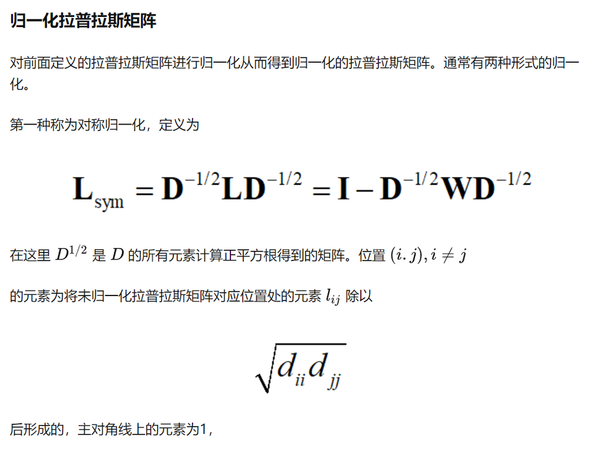

http://tkipf.github.io/graph-convolutional-networks/

https://www.sohu.com/a/342634291_651893

归一化的原因为：若$A=\{a_1,a_2,...,a_n\}$为邻接矩阵，则$f(H^{(l)})=\sigma(AH^{(l)}W^{(l)})$也是一个简单的分类器

- 但是$A$的对角线都为0，这时乘特征矩阵就会忽略掉自身元素对应的特征，只学习了相邻元素的特征
- 如果没有归一化，则$A$会改变$W$的分布，导致不可预知的问题

节点度矩阵$D$为对角矩阵，对角上的元素为各节点度和，即$D=[[cnt(a_1),0,...],[0,cnt(a_2),0,..],[0,0,cnt(a_3),0,...],...]$

至于为什么没有$D^{-1}$，因为这样得到的不是对称矩阵(对角线元素之间不相等)

为什么要用对称矩阵？引用师兄的话

> 因为有向图反映的是从一个节点到另一个节点的结构关系，而很多时候我们要的是这个节点与哪些节点有关系，无向图就更适合反映这样的结构性质

这里可以看出，$A$本身是对称矩阵

对$A$归一化之后，得到矩阵$C=\{c_{ij}\}$

## Numpy的BroadCast机制

https://docs.scipy.org/doc/numpy-1.13.0/user/basics.broadcasting.html

- 相同shape数组乘数组：元素对应相乘
- 数组乘常量：每个元素乘常量，就好像常量拉伸成同样大小的数组一样
- 其它情况：从shape右向左判断，如果相等或其中一个为1，则兼容，否则抛出错误。这时为1的维度就会扩大到另一维度

例如

```
A      (4d array):  8 x 1 x 6 x 1
B      (3d array):      7 x 1 x 5
Result (4d array):  8 x 7 x 6 x 5
```

## 激活函数

$sigmod(x)=\frac{1}{1+e^{-x}}$ 由于边缘梯度小，会导致梯度消失的问题；另外饱和神经元(输入比较大的神经元)会导致这个问题更严重

$ReLU(x)=\begin{cases}x,x>=0\\0,x<0\end{cases}$ ReLU是单侧饱和的，某个特征缺失就是缺失，而不是有缺失的程度，并且计算上也是高效的。但是如果bias较小，会导致反向传播时梯度恒为0，阻碍训练，导致神经元死亡

$LeakyReLU(x)=\begin{cases}x,x>=0\\\alpha x,x<0\end{cases}$，如果$\alpha$为学习参数，则转为$PReLU$，还有随机ReLU

$ELU(x)=\begin{cases}x,x>=0\\\alpha (e^x-1),x<0\end{cases}$

选择先后：ReLU,LeakyReLU/ELU，如果算力足够可以试试PReLU或随机ReLU

## Training Very Deep Networks

主要介绍了一种高速神经网络

对于高速网络，定义两个非线性转换

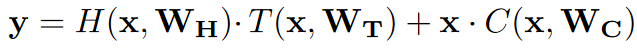

，T是转换门，C是跟随门

得到训练梯度

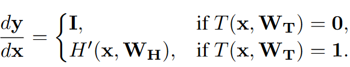

## 参考

https://optimization.cbe.cornell.edu/index.php?title=Main_Page